I downloaded the metadata of the experiment containing the SRR identifiers from the SRA Run Selector (https://www.ncbi.nlm.nih.gov/Traces/study/?query_key=1&WebEnv=NCID_1_49133559_130.14.18.97_5555_1595467779_4208144827_0MetA0_S_HStore&o=acc_s%3Aa)

The following Bash script downloads the raw data using the SRR indentifiers from the Sra Run table.

```r
#!/bin/bash

SRR_ID=$(tail -n +2 ~/project_virus_2020/project_virus_2020/SraRunTable.txt | cut -d ',' -f 1 | sort)

for i in ${SRR_ID}
        do
                echo 'Downloading the following SRA record:' ${i}
                prefetch ${i}
                fastq-dump --gzip --defline-qual '+' ${i}/${i}.sra
        done
```

After obtaining the sequencing data I ran FastQC and MultiQC to check the quality of the reads.

```r
#!/bin/bash

mkdir fastqc_output

fastqc -o fastqc_output ../0_raw_data/*fastq.gz

multiqc fastqc_output/
```

The MultiQC report shows high mean quality scores for all base calls, but there is also an indication of adapter contamination.

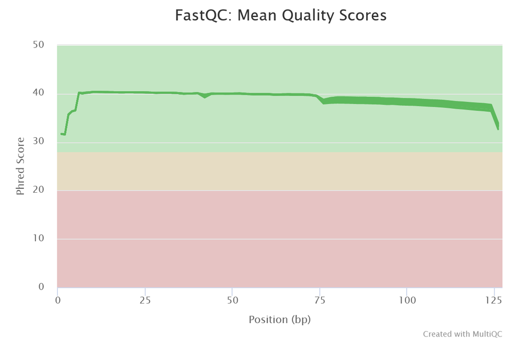

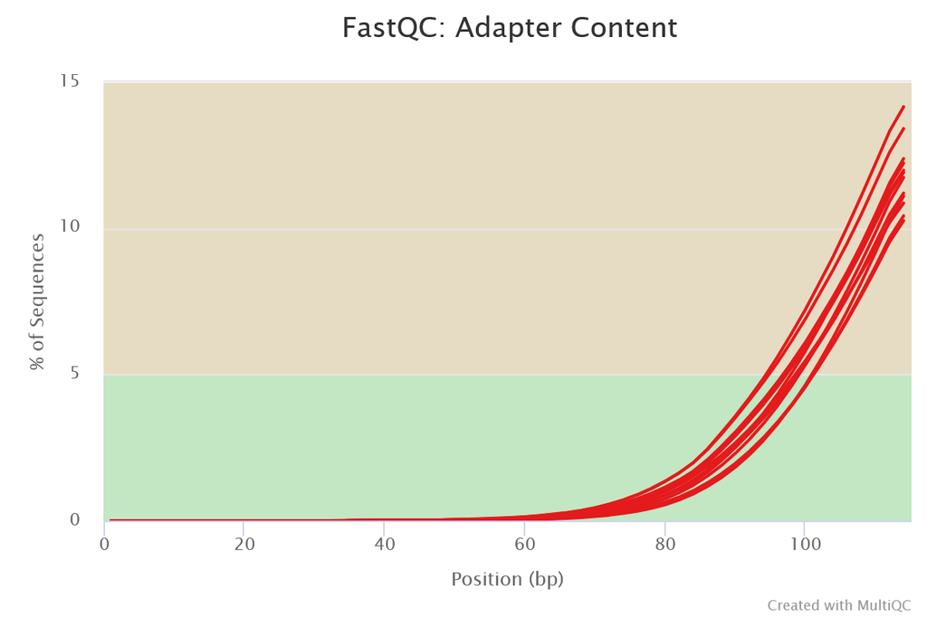

The adaptor contamination was removed by the following script using trimmomatic.

```r
#!/bin/bash

# FastQC report shows presence of Illumina adaptors in all samples

BASE_DIR=/home/anita/project_virus_2020/0_raw_data
TRIM_DIR=/home/anita/miniconda3/pkgs/trimmomatic-0.39-1/share/trimmomatic-0.39-1
ADAPTERS=${TRIM_DIR}/adapters/TruSeq3-SE.fa

mkdir trimmed_fastq

for i in ${BASE_DIR}/*fastq.gz
        do
                SAMPLE=$(basename ${i} .fastq.gz)
                echo 'Start of trimming ' ${SAMPLE}
                java -jar ${TRIM_DIR}/trimmomatic.jar \
                                                SE \
                                                -phred33 \
                                                -threads 6 \
                                                ${i} \
                                                trimmed_fastq/${SAMPLE}.trimmed.fastq.gz \
                                                ILLUMINACLIP:${ADAPTERS}:2:30:10
                echo 'End of trimming ' ${SAMPLE}

        done
```

I performed quality control again to check whether the adaptors were successfully removed from the reads.

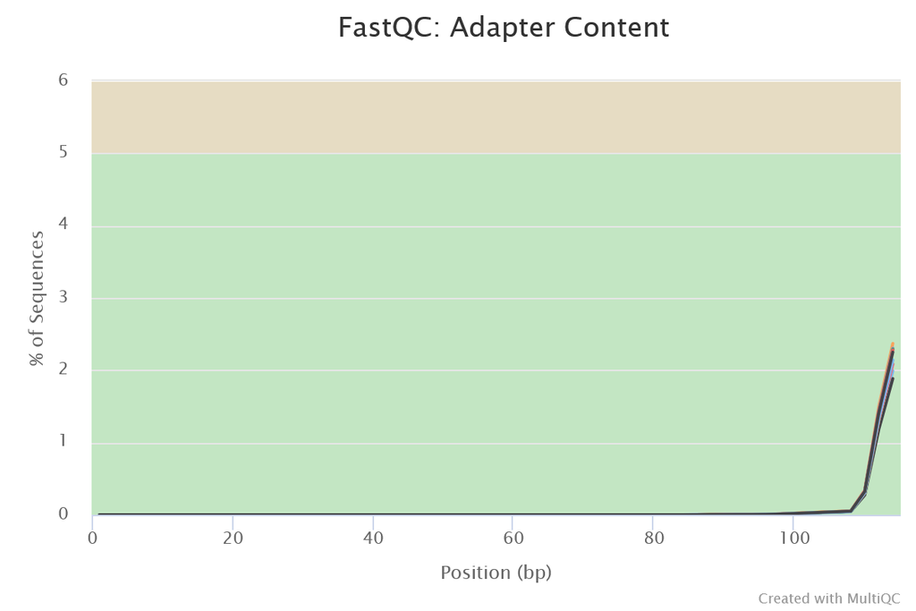

I mapped the trimmed reads to the reference human genome with Salmon using the following script.

```r
#!/bin/bash

BASE_DIR=/home/anita/project_virus_2020

FASTQ_FILES=${BASE_DIR}/1_QC/1_trimmed_fastQC/trimmed_fastq

mkdir salmon_output

echo 'Downloading the human reference genome from GENCODE'

wget ftp://ftp.ebi.ac.uk/pub/databases/gencode/Gencode_human/release_34/gencode.v34.transcripts.fa.gz

echo 'Generating a Salmon index'

salmon index -i human.v34.index -t gencode.v34.transcripts.fa.gz

echo 'Start of RNA quantification with Salmon'

for i in ${FASTQ_FILES}/*.fastq.gz
        do
                SAMPLE=$(basename ${i} .fastq.gz)
                echo 'Start of RNA quantification of' ${SAMPLE}
                salmon quant -i human.v34.index \
                                -l A \
                                -r ${i} \
                                -o salmon_output/${SAMPLE} \
                                -p 6 \
                                --validateMappings \
                                --gcBias \
                                --seqBias
                echo 'End of RNA quantification of ' ${SAMPLE}
        done
```

I created a map between the Ensembl transcript ID and Ensembl gene ID with the following script which is going to be used by the “tximport” package in R:

```r
#!/bin/bash

zless gencode.v34.transcripts.fa.gz | grep -Po 'ENST\d{11}' > enst.txt

zless gencode.v34.transcripts.fa.gz | grep -Po 'ENSG\d{11}' > ensg.txt

paste -d ',' enst.txt ensg.txt > project_2020_gene_map.csv

rm enst.txt ensg.txt
```

After running these scripts I obtained the necessary information to start the analysis in R.

## Additional scripts using STAR and Htseq

In order to compare the results by Salmon I also used STAR for mapping purposes and quantification alongside Htseq.

The STAR script I used to create an index for the human genome and map the reads is the following:

```r
#!/bin/bash

BASE_DIR=/home/anita/project_virus_2020
FASTQ_FILES=${BASE_DIR}/1_QC/trimmed_fastq
OUT_DIR=${BASE_DIR}/2_rna_count/1_STAR/STAR_alignments

mkdir ${OUT_DIR}

mkdir STAR_v34_index




echo 'Start of downloading the primary assembly of the human reference genome'

wget ftp://ftp.ebi.ac.uk/pub/databases/gencode/Gencode_human/release_34/GRCh38.primary_assembly.genome.fa.gz

# STAR requires the genome fasta and annotation file to be unzipped

gunzip GRCh38.primary_assembly.genome.fa.gz

echo 'End of downloading the primary assembly'



echo 'Start of downloading the gene annotation of the human reference genome'

wget ftp://ftp.ebi.ac.uk/pub/databases/gencode/Gencode_human/release_34/gencode.v34.annotation.gtf.gz

gunzip gencode.v34.annotation.gtf.gz

echo 'End of downloading the gene annotation'




echo 'Start of generating a STAR index'

/home/anita/software/STAR-2.7.4a/bin/Linux_x86_64/STAR --runMode genomeGenerate \
        --runThreadN 10 \
        --genomeDir STAR_v34_index \
        --genomeFastaFiles GRCh38.primary_assembly.genome.fa \
        --sjdbGTFfile gencode.v34.annotation.gtf \
        # based on the MultiQC report the sequence length is 126 bp and sjdbOverhang = ReadLength-1
        --sjdbOverhang 125 \
        --limitGenomeGenerateRAM=150000000000

echo 'End of generating the STAR index'

echo 'Start of mapping the reads to the STAR genome index'

mkdir STAR_align

for i in trimmed_fastq/*.fastq.gz
        do
                SAMPLE=$(basename ${i} .trimmed.fastq.gz)
                echo 'Start of mapping ' ${SAMPLE}
                /home/anita/software/STAR-2.7.4a/bin/Linux_x86_64/STAR --runMode alignReads \
                        --outFileNamePrefix /home/anita/project_virus/virus_trimmed_2020/STAR_align/${SAMPLE}_ \
                        --runThreadN 10 \
                        --genomeDir /home/anita/project_virus/virus_trimmed_2020/STAR_v34_index \
                        --readFilesIn ${i} \
                        --readFilesCommand zcat \
                        --outSAMtype BAM SortedByCoordinate \
                        --twopassMode Basic \
                        --twopass1readsN -1
                echo 'End of mapping' ${SAMPLE}
        done

echo 'End of mapping the reads to the STAR genome index'
```

The reads were quantified from the resulting BAM files at gene level with Htseq.

```r
BAM_DIR=/home/anita/project_virus/virus_trimmed_2020/STAR_align

mkdir htseq_count

# Salmon previously detected SR library type, a stranded single-end protocol where the reads come from the reverse strand, so I added "reverse" for the "-s" stranded option

for i in ${BAM_DIR}/*.bam

        do
                SAMPLE=$(basename ${i} _Aligned.sortedByCoord.out.bam)

                echo "Quantifying genes in" ${SAMPLE}

                htseq-count     -f bam \
                                -t gene \
                                -s reverse \
                                ${i} \
                                gencode.v34.annotation.gtf > htseq_count/${SAMPLE}

        done
```

The result is a two-column table for each sample containing the gene ID-s and the number of reads that were mapped to them. I created a table including the count number for all samples with the following script:

```r
mkdir result_htseq


# retrieving the gene ID-s (the last 5 lines contain general information about the reads, so they were not included)
head -n -5 htseq_count/SRR9602253 | cut -f 1 > htseq_gene_id.txt

# retrieving the gene counts of each samples
for i in htseq_count/*

        do
                SAMPLE=$(basename ${i})
                head -n -5 ${i} | cut -f 2 > result_htseq/${SAMPLE}

        done


# creating the count table and the header separately which will be merged after the loop

# adding a header name for the first column which contains the gene ID-s
echo "gene_id" > htseq_header_names.txt

for i in result_htseq/*

        do
                SAMPLE=$(basename ${i})
                # expanding the count table with the next gene count in the loop
                paste htseq_gene_id.txt ${i} > temp_table.txt
                mv temp_table.txt htseq_gene_id.txt

                # expanding the header row with the name of the sample
                echo ${SAMPLE} > sample_name.txt
                paste htseq_header_names.txt sample_name.txt >  temp_header.txt
                mv temp_header.txt htseq_header_names.txt
                rm sample_name.txt
        done

# appending the header names with the counts
cat htseq_gene_id.txt >> htseq_header_names.txt

mv htseq_header_names.txt count_table_htseq

# removing the created files used in the process
rm -r result_htseq htseq_gene_id.txt
```

The result is a count table that can be used in R for differential expression analysis.

In the third quantifying approach I used STAR for mapping the reads and quantifying them rigth away with the “–quantMode GeneCounts” option. As the STAR genome index was already created I reused it in the script below:

```r
mkdir quantmode_result

for i in trimmed_fastq/*.fastq.gz
        do
                SAMPLE=$(basename ${i} .trimmed.fastq.gz)
                echo 'Start of mapping ' ${SAMPLE}
                /home/anita/software/STAR-2.7.4a/bin/Linux_x86_64/STAR --runMode alignReads \
                        --outFileNamePrefix /home/anita/project_virus/virus_trimmed_2020/quantmode_result/${SAMPLE}_ \
                        --runThreadN 10 \
                        --genomeDir /home/anita/project_virus/virus_trimmed_2020/STAR_v34_index \
                        --readFilesIn ${i} \
                        --readFilesCommand zcat \
                        --outSAMtype BAM SortedByCoordinate \
                        --twopassMode Basic \
                        --twopass1readsN -1 \
                        --quantMode GeneCounts
                echo 'End of mapping' ${SAMPLE}
        done
```

Beside the previously resulted STAR files the “–quantMode GeneCounts” option creates a “ReadsPerGene.out.tab” for each sample. In this four-column table the first column contains the gene ID-s and the other three the gene counts with different strandedness options. With the following script I created a table with all the gene counts for all samples, similarly to the Htseq count table above.

```r
#!/bin/bash


mkdir count_result_quantmode


# retrieving the gene ID-s (the first 4 lines contain general information about the reads, so they are not included)
tail -n +5  quantmode_result/SRR9602253_ReadsPerGene.out.tab | cut -f 1 > gene_id.txt


# retrieving the gene counts
# the 4th column was used as based on the STAR manual it contains the "counts for the 2nd read strand aligned with RNA  (htseq-count option -s reverse)"

for i in quantmode_result/*ReadsPerGene.out.tab

        do
                SAMPLE=$(basename ${i} _ReadsPerGene.out.tab)
                tail -n +5 ${i} | cut -f 4 > count_result_quantmode/${SAMPLE}

        done


# creating the count table and the header separately which will be merged after the loop

# adding a header name for the first column which contains the gene ID-s
echo "gene_id" > header_names.txt

for i in count_result_quantmode/*

        do
                SAMPLE=$(basename ${i})
                # expanding the count table with the next gene count in the loop
                paste gene_id.txt ${i} > temp_table.txt
                mv temp_table.txt gene_id.txt

                # expanding the header row with the name of the sample
                echo ${SAMPLE} > sample_name.txt
                paste header_names.txt sample_name.txt >  temp_header.txt
                mv temp_header.txt header_names.txt
                rm sample_name.txt
        done

# appending the header names with the counts
cat gene_id.txt >> header_names.txt

mv header_names.txt count_table_quantmode

# removing the created files used in the process
rm -r count_result_quantmode gene_id.txt
```

The result is a count table which can also be used in R for differential expression analysis and comparison.